# Análisis de los cambios entre la versión del 2005 y la versión original de 1980 de la Constitución Política de la República de Chile

clbustos

1/11/2019

# Objetivo

El objetivo del siguiente análisis es identificar en qué porcentaje la versión del 2005 de la Constitución Política de la República de Chile ha sido modificada desde la versión de 1980.

Para ello, en un primer momento se realizó un análisis párrafo a párrafo, el cual se identificaron los párrafos que presentan la misma redacción y, en aquellos con redacción distinta, la distancia entre las cadenas usando la distancia de Levenshtein (https://es.wikipedia.org/wiki/Distancia_de_Levenshtein). Estos resultados se almacenaron en el archivo d2005_1980.csv.

Posteriormente, de forma manual se verificó el tipo de cambio en 4 categorías

- sin_cambio: el párrafo permanece igual. Se consideran aquí también los casos en que se fundieron el número del Capítulo con su nombre
- cambio_menor: se consideraron como cambios menores aquellos que corresponden a la numeración de los artículos, que cambian de una versión a otra sin alterar el sentido
- cambio_mayor: se presentan cambios en el párrafo que lo alteran de manera más o menos importante. Puede ir desde el cambio de una palabra que refleja la duración de un cargo, hasta la eliminación o agregado de frases completas
- no_hay_parecido: Es un párrafo que no presenta ningún otro similar en la versión antigua.

Analizaremos primero por párrafos, para después intentar hacer un análisis por palabra

# Análisis por párrafo

Podemos observar que el análisis considera 706 párrafos. un 48% de los párrafos no presenta mayor cambio, un 1.84% presenta cambios menores y un 19.5% presenta cambios mayores. Un 30.3% de los párrafos corresponde a nuevos articulos, no presentes previamente.

```r
library(openxlsx)
a<-read.xlsx("d2005_1980.xlsx")
n.tipos=table(a$tipo_cambio)
p.tipos=as.numeric(prop.table(table(a$tipo_cambio)))*100
data.frame(n.tipos, p.tipos)
```

```
##              Var1 Freq  p.tipos
## 1    cambio_mayor  138 19.54674
## 2    cambio_menor   13  1.84136
## 3 no_hay_parecido  214 30.31161
## 4      sin_cambio  341 48.30028
```

Es conveniente ponderar el resultado previo por el número de caracteres en cada párrafo. Podemos observar que la cantidad de caracteres en párrafos que permanece igual disminuye,siendo un 39% del total. Se observa que la cantidad de caracteres de los párrafos que mostrarían un cambio mayor es un 26% del total.

```r
carac.por.tipo<-aggregate(a$texto_origen_n,list(tipo=a$tipo_cambio),sum)
total.carac<-sum(carac.por.tipo$x)
carac.por.tipo$p<-100*carac.por.tipo$x/total.carac
data.frame(carac.por.tipo)
```

```
##              tipo     x         p
## 1    cambio_mayor 43884 26.121118
## 2    cambio_menor  2313  1.376769
## 3 no_hay_parecido 56033 33.352579
## 4      sin_cambio 65772 39.149534
```

# Análisis de modificaciones mayores

Considerando el alto porcentaje de párrafos modificados, es conveniente tener una idea de cuanta grande fue el cambio realizado. Si usamos como indicador el cociente entre la distancia de Levenshtein y el largo del párrafo, podemos observar que la media de cambio es de .34 (DE=0.2), con un mínimo de 0.02 y un máximo de .69. Si observamos la distribución, esta es prácticamente uniforme en el rango.

```r
a.cambio.mayor<-a[a$tipo_cambio=="cambio_mayor",]
p.cambio<-a.cambio.mayor$distancia/a.cambio.mayor$texto_origen_n
psych::describe(p.cambio)
```

```
##    vars   n mean  sd median trimmed  mad  min  max range skew kurtosis
## X1    1 138 0.34 0.2   0.34    0.34 0.26 0.02 0.69  0.67 0.05     -1.3
##      se
## X1 0.02
```

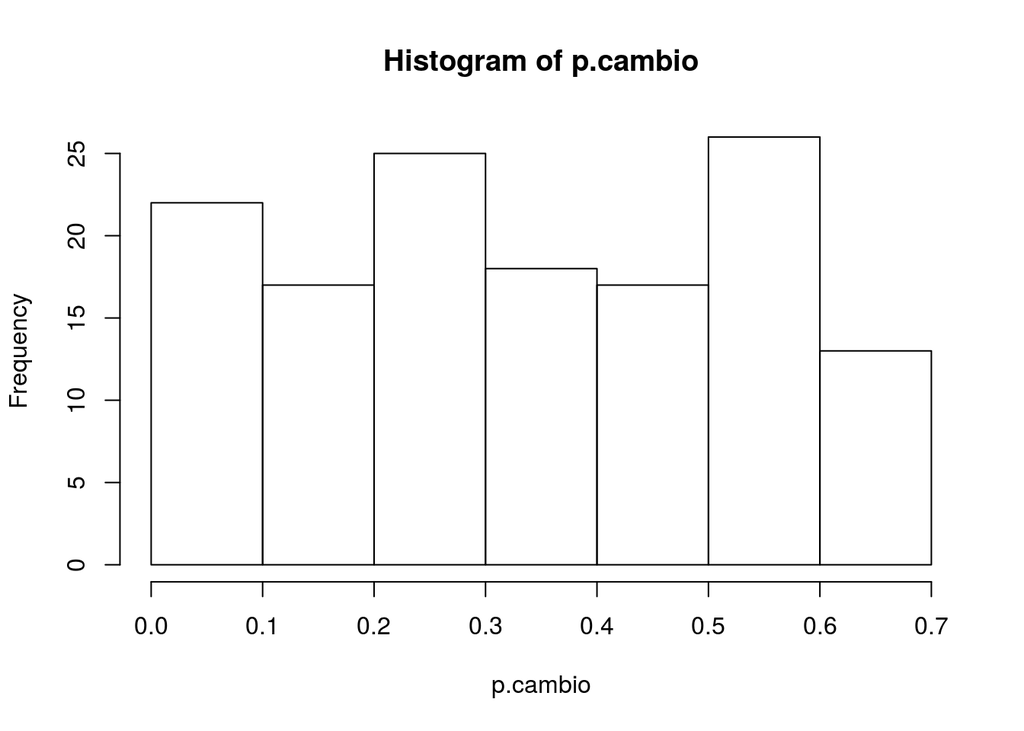

```r
hist(p.cambio)
```

# Distribución de los cambios

El mayor cambio se observa a partir del párrafo 500, con el Capítulo VIII relacionado al tribunal constitucional. Muchos de las innovaciones se observan tras el párrafo 600, con el Capítulo XIV, que regula los gobiernos regionales.

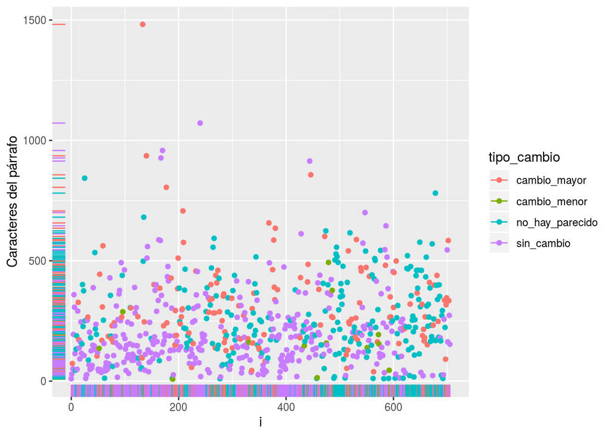

```r
ggplot(a,aes(x=i,y=texto_origen_n, color=tipo_cambio))+geom_point()+geom_rug()+ylab("Caracteres del párrafo")
```

# Conclusión

Existe un importante porcentaje de la Constitución en su versión del 2005, cercano al 40% de su contenido, que no ha cambiado en absoluto desde la versión de 1980. Existen, sin embargo, considerables cambios en términos de adiciones, particularmente de las funciones del cuerpo legislativo, así como cambios en el Tribunal Constitucional y los Gobiernos regionales.